# RAINLINK Notebook

The RAINLINK package. Retrieval algorithm for rainfall mapping from microwave links in a cellular communication network.

Version 1.14 Copyright (C) 2019 Aart Overeem

This program is free software: you can redistribute it and/or modify it under the terms of the GNU General Public License as published by the Free Software Foundation, either version 3 of the License, or (at your option) any later version.

This program is distributed in the hope that it will be useful, but WITHOUT ANY WARRANTY; without even the implied warranty of MERCHANTABILITY or FITNESS FOR A PARTICULAR PURPOSE. See the GNU General Public License for more details.

You should have received a copy of the GNU General Public License along with this program. If not, see http://www.gnu.org/licenses/.

Note that it is not necessarily a problem if a function argument is not supplied to the function. If the function argument is not used, then there is no problem. Only be aware that you should use e.g. MaxFrequency=MaxFrequency. I.e. if you only supply MaxFrequency and the function argument before MaxFrequency is missing, than the function will not execute properly.

# 0. Load R libraries, parameter values, and other settings.

If the time zone of the employed microwave link dataset is not the same as the (local) time zone used by R on your computer, set the time zone of the microwave link dataset: (this is important for functions RefLevelMinMaxRSL, WetDryNearbyLinkApMinMaxRSL and Interpolation):

```r
Sys.setenv(TZ='UTC')
```

Otherwise RAINLINK can derive a wrong time interval length due to going to or from daylight saving time (DST). Timing of DST may be different between time zones, or one time zone may not have a change to/from DST.

# 1. PreprocessingMinMaxRSL

```r
# Load data:
load("data/Linkdata_vodafone2016.RData")
# summary(Linkdata)
# Add column with polarization if this column is not supplied in the link data:
if ("Polarization" %in% names(Linkdata)==FALSE)
{
  Linkdata$Polarization <- rep(NA,nrow(Linkdata))
}
```

When no information on polarization is provided, the above code creates a column of NA for Polarization. In the function “RainRetrievalMinMaxRSL.R” links with NA values for polarization are processed with a & b values determined for vertically polarized signals. If information on polarization of links is available, use H for horizontally polarized & V for vertically polarized in “Linkdata Polarization”. H, V & NA may occur in the same Linkdata file.

```r
# Run R function:
StartTime <- proc.time()
DataPreprocessed <- PreprocessingMinMaxRSL(Data=Linkdata,
                                           MaxFrequency=MaxFrequency,
                                           MinFrequency=MinFrequency,
                                           verbose=TRUE)
cat(sprintf("Finished. (%.1f seconds)\n",round((proc.time()-StartTime)[3],digits=1))) # ~ 360 s
```

```
Finished. (319.6 seconds)
```

```r
summary(DataPreprocessed)
```

```
   Frequency             DateTime            Pmin              Pmax           PathLength
 Min.   : 6.00   201606290945:    641   Min.   :-108.00   Min.   :-100.00   Min.   : 0.1618
 1st Qu.:17.75   201606291015:    641   1st Qu.: -49.00   1st Qu.: -48.00   1st Qu.: 1.9777
 Median :19.53   201606291030:    641   Median : -44.00   Median : -44.00   Median : 4.0783
 Mean   :23.38   201606291100:    641   Mean   : -44.95   Mean   : -43.98   Mean   : 5.4344
 3rd Qu.:23.05   201606291115:    641   3rd Qu.: -40.00   3rd Qu.: -39.00   3rd Qu.: 7.1872
 Max.   :42.59   201606291130:    641   Max.   : -21.00   Max.   : -16.00   Max.   :29.7374
                 (Other)     :5481725
     XStart           YStart           XEnd             YEnd                   Label
 Min.   : 9.617   Min.   :44.09   Min.   : 9.617   Min.   :44.09   2-Q6885/2-Q6886:  24684
 1st Qu.:10.328   1st Qu.:44.37   1st Qu.:10.328   1st Qu.:44.37   2-Q7825/2-Q7826:  24680
 Median :11.147   Median :44.51   Median :11.147   Median :44.51   2-P9739/2-P9740:  24670
 Mean   :10.915   Mean   :44.52   Mean   :10.915   Mean   :44.52   2-Q7935/2-Q7936:  24660
 3rd Qu.:11.347   3rd Qu.:44.69   3rd Qu.:11.347   3rd Qu.:44.69   2-Q2081/2-Q2082:  24654
 Max.   :11.753   Max.   :45.01   Max.   :11.753   Max.   :45.01   2-Q3655/2-Q3656:  24648
                                                                   (Other)        :5337575
 Polarization    ATPCflag         ATPCvalue         Direction             ID
 H   :1234217   Mode :logical   Min.   :-11       forward:2728159   Min.   :  2.0
 V   :4032743   FALSE:1055009   1st Qu.: -4       back   :2757412   1st Qu.:161.0
 NA's: 218611   TRUE :4430562   Median : -2                         Median :359.0
                                Mean   : -3                         Mean   :344.5
                                3rd Qu.: -2                         3rd Qu.:517.0
                                Max.   : -1                         Max.   :713.0
                                NA's   :5349675
```

# 2. WetDryNearbyLinkApMinMaxRSL

```r
# Run R function:
StartTime <- proc.time()
WetDry <- WetDryNearbyLinkApMinMaxRSL(Data=DataPreprocessed,
                                      CoorSystemInputData=NULL,
                                      MinHoursPmin=MinHoursPmin,
                                      PeriodHoursPmin=PeriodHoursPmin,
                                      Radius=Radius,
                                      Step8=Step8,
                                      ThresholdMedian=ThresholdMedian,
                                      ThresholdMedianL=ThresholdMedianL,
                                      ThresholdNumberLinks=ThresholdNumberLinks,
                                      ThresholdWetDry=ThresholdWetDry)
cat(sprintf("Finished. (%.1f seconds)\n",round((proc.time()-StartTime)[3],digits=1)))  # ~ 3100 s
```

```
Finished. (4087.7 seconds)
```

```r
summary(WetDry)
```

```
      Dry               F
 Min.   :0.00     Min.   :-2511.369
 1st Qu.:1.00     1st Qu.:   -5.669
 Median :1.00     Median :   -0.768
 Mean   :0.96     Mean   :   -6.304
 3rd Qu.:1.00     3rd Qu.:    1.092
 Max.   :1.00     Max.   :   49.223
 NA's   :223621   NA's   :5512
```

# 3. RefLevelMinMaxRSL

```r
# Run R function:
StartTime <- proc.time()
Pref <- RefLevelMinMaxRSL(Data=DataPreprocessed,
                          Dry=WetDry$Dry,
                          HoursRefLevel=HoursRefLevel,
                          PeriodHoursRefLevel=PeriodHoursRefLevel)
cat(sprintf("Finished. (%.1f seconds)\n",round((proc.time()-StartTime)[3],digits=1))) # ~ 5610 s
```

```
Finished. (7180.0 seconds)
```

```r
summary(Pref)
```

```
   Min. 1st Qu.  Median    Mean 3rd Qu.    Max.    NA's
-102.50  -48.00  -44.00  -44.17  -39.50  -21.00  229560
```

# 4. OutlierFilterMinMax

```r
# Run R function:
DataOutlierFiltered <- OutlierFilterMinMaxRSL(Data=DataPreprocessed,
                                              F=WetDry$F,
                                              FilterThreshold=FilterThreshold)
summary(DataOutlierFiltered)
```

```
   Frequency             DateTime            Pmin              Pmax           PathLength
 Min.   : 6.00   201606290945:    641   Min.   :-108.00   Min.   :-100.00   Min.   : 0.1618
 1st Qu.:17.75   201606291015:    641   1st Qu.: -49.00   1st Qu.: -48.00   1st Qu.: 1.9777
 Median :19.53   201606291030:    641   Median : -44.00   Median : -44.00   Median : 4.0783
 Mean   :23.38   201606291100:    641   Mean   : -44.92   Mean   : -43.98   Mean   : 5.4344
 3rd Qu.:23.05   201606291115:    641   3rd Qu.: -40.00   3rd Qu.: -39.00   3rd Qu.: 7.1872
 Max.   :42.59   201606291130:    641   Max.   : -21.00   Max.   : -16.00   Max.   :29.7374
                 (Other)     :5481725   NA's   :259220
     XStart           YStart           XEnd             YEnd                   Label
 Min.   : 9.617   Min.   :44.09   Min.   : 9.617   Min.   :44.09   2-Q6885/2-Q6886:  24684
 1st Qu.:10.328   1st Qu.:44.37   1st Qu.:10.328   1st Qu.:44.37   2-Q7825/2-Q7826:  24680
 Median :11.147   Median :44.51   Median :11.147   Median :44.51   2-P9739/2-P9740:  24670
 Mean   :10.915   Mean   :44.52   Mean   :10.915   Mean   :44.52   2-Q7935/2-Q7936:  24660
 3rd Qu.:11.347   3rd Qu.:44.69   3rd Qu.:11.347   3rd Qu.:44.69   2-Q2081/2-Q2082:  24654
 Max.   :11.753   Max.   :45.01   Max.   :11.753   Max.   :45.01   2-Q3655/2-Q3656:  24648
                                                                   (Other)        :5337575
 Polarization    ATPCflag         ATPCvalue         Direction             ID
 H   :1234217   Mode :logical   Min.   :-11       forward:2728159   Min.   :  2.0
 V   :4032743   FALSE:1055009   1st Qu.: -4       back   :2757412   1st Qu.:161.0
 NA's: 218611   TRUE :4430562   Median : -2                         Median :359.0
                                Mean   : -3                         Mean   :344.5
                                3rd Qu.: -2                         3rd Qu.:517.0
                                Max.   : -1                         Max.   :713.0
                                NA's   :5349675
```

# 5. CorrectMinMaxRSL

```r
# Run R function:
Pcor <- CorrectMinMaxRSL(Data=DataOutlierFiltered,
                         Dry=WetDry$Dry,
                         Pref=Pref)
summary(Pcor)
```

```
    PminCor          PmaxCor
 Min.   :-106.0   Min.   :-102.5
 1st Qu.: -48.0   1st Qu.: -48.0
 Median : -44.0   Median : -44.0
 Mean   : -44.3   Mean   : -44.2
 3rd Qu.: -40.0   3rd Qu.: -39.5
 Max.   : -21.0   Max.   : -21.0
 NA's   :478700   NA's   :478700
```

# 6. RainRetrievalMinMaxRSL

```r
kRPowerLawDataH <- read.table(FileRainRetrHorizontal)
colnames(kRPowerLawDataH) <- c("f", "a", "b")
kRPowerLawDataV <- read.table(FileRainRetrVertical)
colnames(kRPowerLawDataV) <- c("f", "a", "b")
# Run R function:
StartTime <- proc.time()
Rmean <- RainRetrievalMinMaxRSL(Aa=Aa,
                                alpha=alpha,
                                Data=DataOutlierFiltered,
                                kRPowerLawDataH=kRPowerLawDataH,
                                kRPowerLawDataV=kRPowerLawDataV,
                                PmaxCor=Pcor$PmaxCor,
                                PminCor=Pcor$PminCor,
                                Pref=Pref)
cat(sprintf("Finished. (%.1f seconds)\n",round((proc.time()-StartTime)[3],digits=1))) # ~ 20 s
```

```
Finished. (23.3 seconds)
```

```r
summary(Rmean)
```

```
   Min. 1st Qu.  Median    Mean 3rd Qu.    Max.    NA's
    0.0     0.0     0.0     0.1     0.0   208.3  478700
```

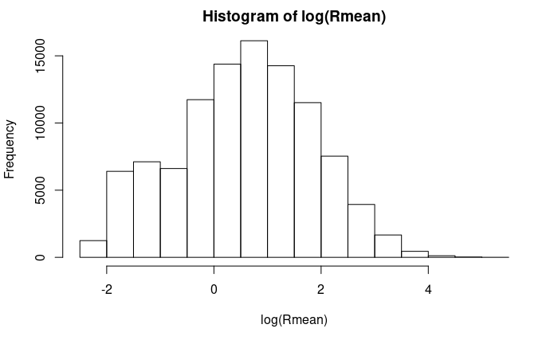

```r
hist(log(Rmean))
```